# Mode Choice Calibration

Chris Day

3/2/2022

```r
library(tidyverse)
library(scales)
```

# Introduction

It is time to calibrate the mode choice constants. To do this, we will calibrate modal shares based on trips of each tour purpose for differing auto deficiency classes. The target shares will be those that were calculated from ActivitySim. These targets are shown in the output of ActivitySim or the input to BEAM.

To do this calibration, we will compare the targets file with the ith.events.csv file of a run done with mode innovation turned on (where ith is the last iteration.) We will use the formula below to the calibration:

$NewASC = OldASC + ln(Trips_{ASIM}/Trips_{BEAM})$

where each formula is dependent on purpose, mode, and auto deficiency. # BEAM final

```r
#tripArrivals <- csvevents2.5k %>%
#  arrange(person,tourIndex,activityIndex) %>%
#  mutate(person = as.numeric(person),
#         activityIndex = as.numeric(activityIndex)) %>%
#  select(person,tourIndex,activityIndex,actType,locationX,locationY,mode)
```

# Target Values

First, lets create a table of the target trip values that we want dependent on tour purpose and auto deficiency. This is done below.

To do that, lets first read in the ActivitySim final trips file. Lets also create a new variable called the activity_index variable.

```r
asim_final_trips <- read_csv("events/final_trips_100k.csv") %>%
  # determine start and end time of each tour
  arrange(person_id, tour_id) %>%
  group_by(person_id, tour_id) %>%
  mutate(tour_start_time = min(depart), tour_end_time = max(depart)) %>% ungroup() %>%
  # restructure tour index order using tour start/end times
  arrange(person_id,depart,tour_start_time,tour_end_time,trip_id) %>%
  group_by(person_id) %>%
  # create new attribute called activity_index
  mutate(activity_index = row_number() -1) %>% ungroup() %>%
  # select the needed columns
  select(trip_id, person_id, tour_id, household_id, activity_index, trip_count, purpose, origin, destination, primary_purpose, trip_mode)
```

Now, lets read in the ActivitySim final households file. This file contains data on auto ownership and number of workers per household.

```r
asim_final_households <- read_csv("events/final_households_100k.csv") %>%
  mutate(autoWorkRatio = ifelse(auto_ownership == 0, "no_auto", ifelse(auto_ownership >= num_workers, "auto_sufficient", "auto_deficient")))
```

Now lets merge the two datasets together.

```r
asim_table <- left_join(asim_final_trips, asim_final_households, by = "household_id") %>%
  select(trip_id, person_id, tour_id, household_id, activity_index, trip_count, purpose, origin, destination, autoWorkRatio, primary_purpose, trip_mode)
```

Now we create a data table that shows the values of each ActivitySim trip mode in terms of the modes that BEAM uses.

```r
modes <- data.frame(trip_mode = c("BIKE","WALK","DRIVEALONEFREE","DRIVEALONEPAY","SHARED2FREE","SHARED2PAY","SHARED3FREE","SHARED3PAY","DRIVE_COM","DRIVE_EXP","DRIVE_LOC","DRIVE_LRF","DRIVE_HVY","WALK_COM","WALK_EXP","WALK_LOC","WALK_LRF","WALK_HVY","TNC_SINGLE","TAXI","TNC_SHARED"),beamMode = c("bike","walk","car","car","hov2","hov2","hov3","hov3","drive_transit","drive_transit","drive_transit","drive_transit","drive_transit","walk_transit","walk_transit","walk_transit","walk_transit","walk_transit","ride_hail","ride_hail","ride_hail_pooled"))
modes
```

```
##         trip_mode         beamMode
## 1            BIKE             bike
## 2            WALK             walk
## 3  DRIVEALONEFREE              car
## 4   DRIVEALONEPAY              car
## 5     SHARED2FREE             hov2
## 6      SHARED2PAY             hov2
## 7     SHARED3FREE             hov3
## 8      SHARED3PAY             hov3
## 9       DRIVE_COM    drive_transit
## 10      DRIVE_EXP    drive_transit
## 11      DRIVE_LOC    drive_transit
## 12      DRIVE_LRF    drive_transit
## 13      DRIVE_HVY    drive_transit
## 14       WALK_COM     walk_transit
## 15       WALK_EXP     walk_transit
## 16       WALK_LOC     walk_transit
## 17       WALK_LRF     walk_transit
## 18       WALK_HVY     walk_transit
## 19     TNC_SINGLE        ride_hail
## 20           TAXI        ride_hail
## 21     TNC_SHARED ride_hail_pooled
```

Next, we join the beam mode values and summarize the entire dataset in order to get the percentages of modes based on primary purpose and auto work ratio.

```r
asim_table2 <- inner_join(asim_table,modes, by = "trip_mode") %>%
  group_by(beamMode, autoWorkRatio, primary_purpose) %>%
  summarize(tripTotals = sum(n())) %>% ungroup() %>%
  mutate(total = sum(tripTotals)) %>%
  mutate(tripPercents = tripTotals/total*100) %>%
  select(-total)
asim_table2
```

```
## # A tibble: 241 x 5
##    beamMode autoWorkRatio   primary_purpose tripTotals tripPercents
##    <fct>    <chr>           <chr>                <int>        <dbl>
##  1 bike     auto_deficient  atwork                   5     0.000518
##  2 bike     auto_deficient  escort                   2     0.000207
##  3 bike     auto_deficient  othdiscr                22     0.00228
##  4 bike     auto_deficient  othmaint                 6     0.000622
##  5 bike     auto_deficient  school                  91     0.00943
##  6 bike     auto_deficient  shopping                26     0.00270
##  7 bike     auto_deficient  social                  14     0.00145
##  8 bike     auto_deficient  univ                     5     0.000518
##  9 bike     auto_deficient  work                   413     0.0428
## 10 bike     auto_sufficient atwork                 234     0.0243
## # ... with 231 more rows
```

To visualize the table, below is a graph that shows similar information.

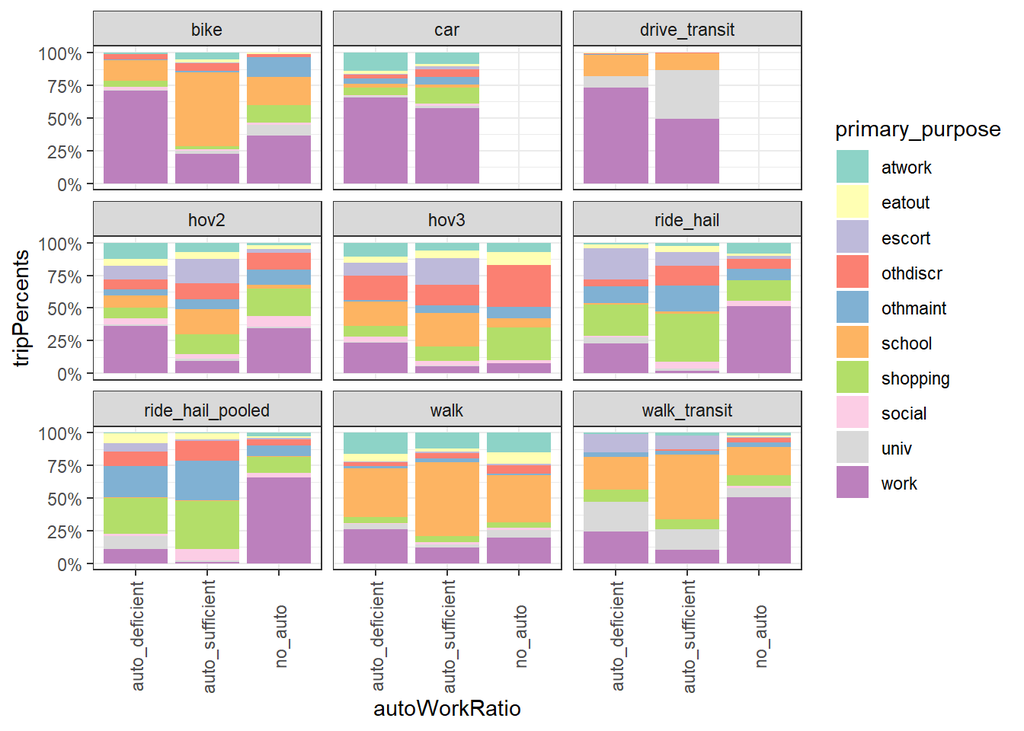

```r
p <- ggplot(asim_table2) +
  aes(autoWorkRatio,tripPercents,fill=primary_purpose) +
  geom_bar(position = "fill", stat = "identity") +
  scale_y_continuous(labels = percent) +
  scale_fill_brewer(palette = "Set3") +
  facet_wrap(~beamMode) +
  theme_bw() +
  theme(axis.text.x = element_text(angle = 90,vjust = 0.5))
p
```